# MUSA 508, Lab 4 - Spatial Machine Learning Pt. 1

Steif, Harris, Fichman - 2020/21

# Big Section Header

You can put some text under the header

## Little Section Header

You can put some text under the header

## Data Wrangling

See if you can change the chunk options to get rid of the text outputs

```r
nhoods <-
  st_read("http://bostonopendata-boston.opendata.arcgis.com/datasets/3525b0ee6e6b427f9aab5d0a1d0a1a28_0.geojson") %>%
  st_transform('ESRI:102286')
boston <-
  read.csv(file.path(root.dir,"/Chapter3_4/bostonHousePriceData_clean.csv"))

boston.sf <-
  boston %>%
  st_as_sf(coords = c("Longitude", "Latitude"), crs = 4326, agr = "constant") %>%
  st_transform('ESRI:102286')


bostonCrimes <- read.csv(file.path(root.dir,"/Chapter3_4/bostonCrimes.csv"))
```

Exploratory data analysis

```r
# finding counts by group
group_by(bostonCrimes, OFFENSE_CODE_GROUP) %>%
  summarize(count = n()) %>%
  arrange(-count) %>% top_n(10) %>%
  kable() %>%
  kable_styling()
```

| OFFENSE_CODE_GROUP | count |
| --- | --- |
| Motor Vehicle Accident Response | 23717 |
| Larceny | 16869 |
| Drug Violation | 15815 |
| Other | 12797 |
| Medical Assistance | 12626 |
| Investigate Person | 10266 |
| Simple Assault | 9932 |
| Vandalism | 8300 |
| Larceny From Motor Vehicle | 8219 |
| Verbal Disputes | 7721 |

See if you can alter the size of the image output.

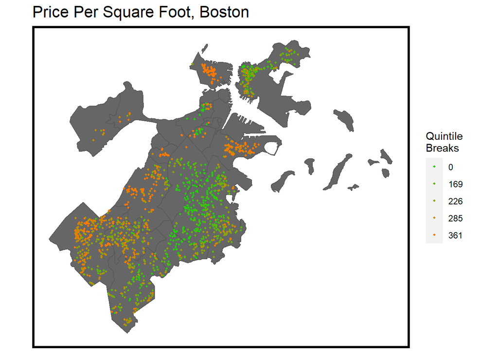

```r
# ggplot, reorder

# Mapping data
ggplot() +
  geom_sf(data = nhoods, fill = "grey40") +
  geom_sf(data = boston.sf, aes(colour = q5(PricePerSq)),
          show.legend = "point", size = .75) +
  scale_colour_manual(values = palette5,
                   labels=qBr(boston,"PricePerSq"),
                   name="Quintile\nBreaks") +
  labs(title="Price Per Square Foot, Boston") +
  mapTheme()
```

Cleaning Crime Data

```r
bostonCrimes.sf <-
  bostonCrimes %>%
    filter(OFFENSE_CODE_GROUP == "Aggravated Assault",
           Lat > -1) %>%
    dplyr::select(Lat, Long) %>%
    na.omit() %>%
    st_as_sf(coords = c("Long", "Lat"), crs = 4326, agr = "constant") %>%
    st_transform('ESRI:102286') %>%
    distinct()
```

```r
# Counts of crime per buffer of house sale
boston.sf$crimes.Buffer =
    st_buffer(boston.sf, 660) %>%
    aggregate(mutate(bostonCrimes.sf, counter = 1),., sum) %>%
    pull(counter)

## Nearest Neighbor Feature
st_c <- st_coordinates

boston.sf <-
  boston.sf %>%
    mutate(
      crime_nn1 = nn_function(st_c(boston.sf), st_c(bostonCrimes.sf), 1),
      crime_nn2 = nn_function(st_c(boston.sf), st_c(bostonCrimes.sf), 2),
      crime_nn3 = nn_function(st_c(boston.sf), st_c(bostonCrimes.sf), 3),
      crime_nn4 = nn_function(st_c(boston.sf), st_c(bostonCrimes.sf), 4),
      crime_nn5 = nn_function(st_c(boston.sf), st_c(bostonCrimes.sf), 5))
```

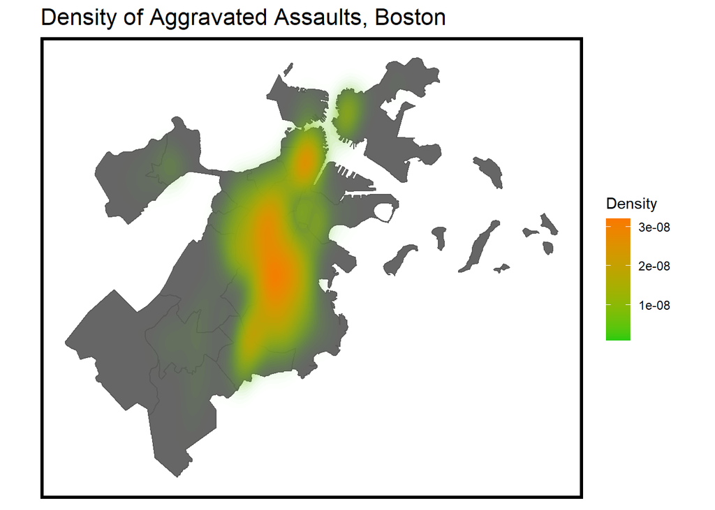

```r
## Plot assault density
ggplot() + geom_sf(data = nhoods, fill = "grey40") +
  stat_density2d(data = data.frame(st_coordinates(bostonCrimes.sf)),
                 aes(X, Y, fill = ..level.., alpha = ..level..),
                 size = 0.01, bins = 40, geom = 'polygon') +
  scale_fill_gradient(low = "#25CB10", high = "#FA7800", name = "Density") +
  scale_alpha(range = c(0.00, 0.35), guide = FALSE) +
  labs(title = "Density of Aggravated Assaults, Boston") +
  mapTheme()
```

## Analyzing associations

Run these code blocks…

Can somebody walk me through what they do?

Can you give me a one-sentence description of what the takeaway is?

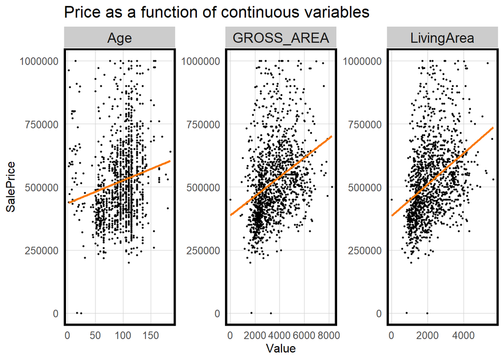

```r
## Home Features cor
st_drop_geometry(boston.sf) %>%
  mutate(Age = 2015 - YR_BUILT) %>%
  dplyr::select(SalePrice, LivingArea, Age, GROSS_AREA) %>%
  filter(SalePrice <= 1000000, Age < 500) %>%
  gather(Variable, Value, -SalePrice) %>%
   ggplot(aes(Value, SalePrice)) +
     geom_point(size = .5) + geom_smooth(method = "lm", se=F, colour = "#FA7800") +
     facet_wrap(~Variable, ncol = 3, scales = "free") +
     labs(title = "Price as a function of continuous variables") +
     plotTheme()
```

Can we resize this somehow to make it look better?

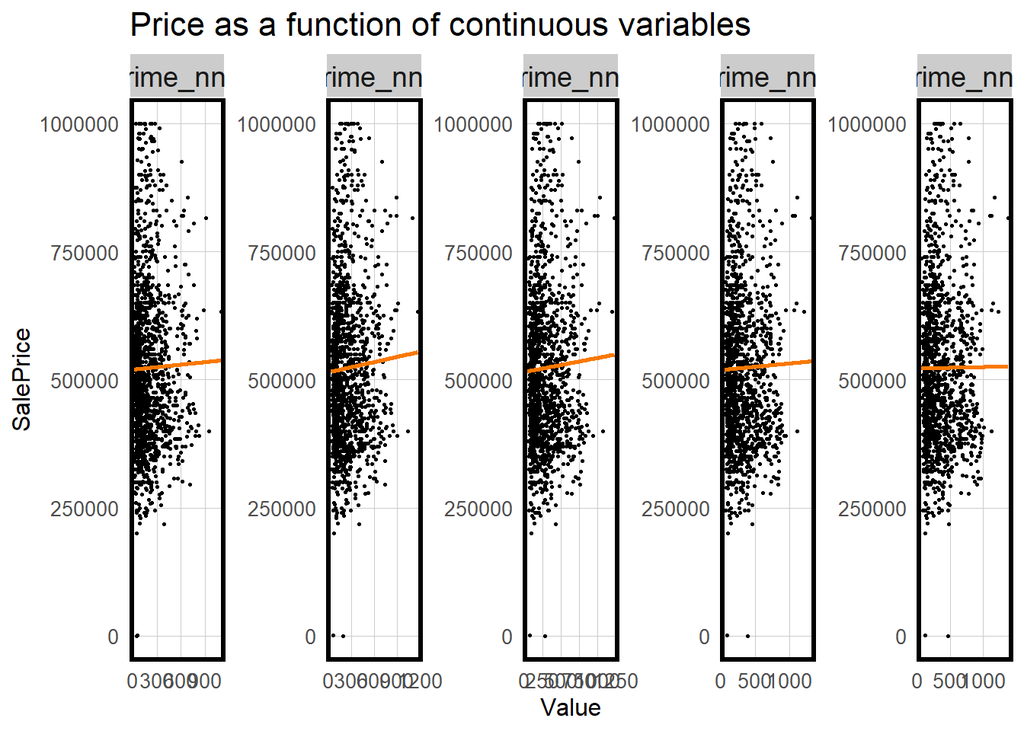

```r
## Crime cor
boston.sf %>%
  st_drop_geometry() %>%
  mutate(Age = 2015 - YR_BUILT) %>%
  dplyr::select(SalePrice, starts_with("crime_")) %>%
  filter(SalePrice <= 1000000) %>%
  gather(Variable, Value, -SalePrice) %>%
   ggplot(aes(Value, SalePrice)) +
     geom_point(size = .5) + geom_smooth(method = "lm", se=F, colour = "#FA7800") +
     facet_wrap(~Variable, nrow = 1, scales = "free") +
     labs(title = "Price as a function of continuous variables") +
     plotTheme()
```

## Correlation matrix

Let’s take a few minutes to interpret this

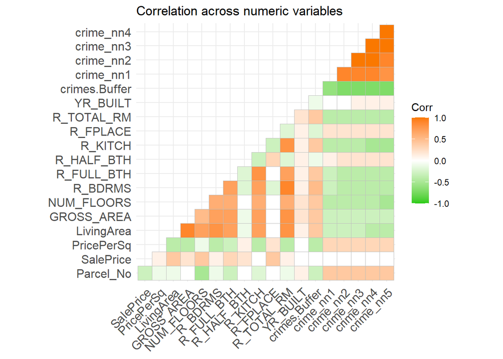

```r
numericVars <-
  select_if(st_drop_geometry(boston.sf), is.numeric) %>% na.omit()

ggcorrplot(
  round(cor(numericVars), 1),
  p.mat = cor_pmat(numericVars),
  colors = c("#25CB10", "white", "#FA7800"),
  type="lower",
  insig = "blank") +
    labs(title = "Correlation across numeric variables")
```

# Univarite correlation -> multi-variate OLS regression

Pearson’s R

```r
cor.test(boston$LivingArea, boston$SalePrice, method = "pearson")
```

```
##
##  Pearson's product-moment correlation
##
## data:  boston$LivingArea and boston$SalePrice
## t = 14.969, df = 1483, p-value < 2.2e-16
## alternative hypothesis: true correlation is not equal to 0
## 95 percent confidence interval:
##  0.3172821 0.4056948
## sample estimates:
##       cor
## 0.3623031
```

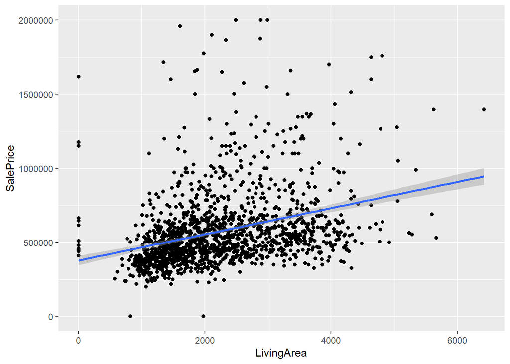

```r
ggplot(filter(boston, SalePrice <= 2000000), aes(y=SalePrice, x = LivingArea)) +
  geom_point() +
  geom_smooth(method = "lm")
```

## Univarite Regrssion

We now have an R-squared value - what’s this good for as a diagnostic of model quality?

Can somebody interpret the coefficient?

```r
livingReg <- lm(SalePrice ~ LivingArea, data = boston)

summary(livingReg)
```

```
##
## Call:
## lm(formula = SalePrice ~ LivingArea, data = boston)
##
## Residuals:
##     Min      1Q  Median      3Q     Max
## -855962 -219491  -68291   55248 9296561
##
## Coefficients:
##              Estimate Std. Error t value Pr(>|t|)
## (Intercept) 157968.32   35855.59   4.406 1.13e-05 ***
## LivingArea     216.54      14.47  14.969  < 2e-16 ***
## ---
## Signif. codes:  0 '***' 0.001 '**' 0.01 '*' 0.05 '.' 0.1 ' ' 1
##
## Residual standard error: 563800 on 1483 degrees of freedom
## Multiple R-squared:  0.1313, Adjusted R-squared:  0.1307
## F-statistic: 224.1 on 1 and 1483 DF,  p-value: < 2.2e-16
```

## Prediction example

Make a prediction using the coefficient, intercept etc.,

```r
new_LivingArea = 4000

# "by hand"
157968.32 + 216.54 * new_LivingArea
```

```
## [1] 1024128
```

```r
# predict() function
predict(livingReg, newdata = data.frame(LivingArea = 4000))
```

```
##       1
## 1024125
```

## plot of marginal regression response

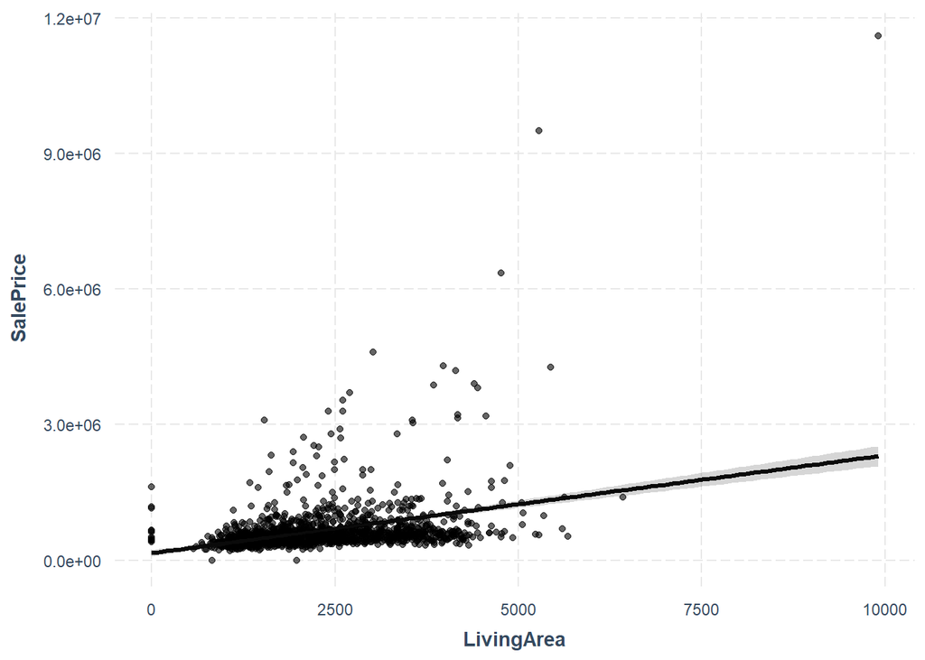

```r
effect_plot(livingReg, pred = LivingArea, interval = TRUE, plot.points = TRUE)
```

## Multivariate Regression

Let’s take a look at this regression - how are we creating it?

What’s up with these categorical variables?

Better R-squared - does that mean it’s a better model?

```r
reg1 <- lm(SalePrice ~ ., data = st_drop_geometry(boston.sf) %>%
                                 dplyr::select(SalePrice, LivingArea, Style,
                                               GROSS_AREA, R_TOTAL_RM, NUM_FLOORS,
                                               R_BDRMS, R_FULL_BTH, R_HALF_BTH,
                                               R_KITCH, R_AC, R_FPLACE))

summary(reg1)
```

```
##
## Call:
## lm(formula = SalePrice ~ ., data = st_drop_geometry(boston.sf) %>%
##     dplyr::select(SalePrice, LivingArea, Style, GROSS_AREA, R_TOTAL_RM,
##         NUM_FLOORS, R_BDRMS, R_FULL_BTH, R_HALF_BTH, R_KITCH,
##         R_AC, R_FPLACE))
##
## Residuals:
##      Min       1Q   Median       3Q      Max
## -1565606  -163087     1436   150214  6812354
##
## Coefficients:
##                      Estimate Std. Error t value Pr(>|t|)
## (Intercept)         294677.70   90767.25   3.247 0.001195 **
## LivingArea             609.35      48.08  12.675  < 2e-16 ***
## StyleCape          -140506.90   79096.26  -1.776 0.075875 .
## StyleColonial      -343096.19   78518.60  -4.370 1.33e-05 ***
## StyleConventional  -261936.77   84123.07  -3.114 0.001883 **
## StyleDecker        -365755.86  102531.33  -3.567 0.000372 ***
## StyleDuplex        -183868.54  128816.91  -1.427 0.153690
## StyleRaised Ranch  -390167.10  109706.56  -3.556 0.000388 ***
## StyleRanch          -92823.33   95704.75  -0.970 0.332261
## StyleRow End        -68636.71   98864.51  -0.694 0.487636
## StyleRow Middle     172722.62  100981.37   1.710 0.087397 .
## StyleSemi?Det      -274145.98   96970.88  -2.827 0.004761 **
## StyleSplit Level   -232288.13  168146.14  -1.381 0.167348
## StyleTri?Level     -803632.08  408127.02  -1.969 0.049134 *
## StyleTudor         -394103.12  408553.66  -0.965 0.334890
## StyleTwo Fam Stack -147538.22   84835.41  -1.739 0.082227 .
## StyleUnknown       -656090.50  291530.26  -2.251 0.024566 *
## StyleVictorian     -507379.65  130751.09  -3.881 0.000109 ***
## GROSS_AREA            -206.26      29.11  -7.086 2.14e-12 ***
## R_TOTAL_RM          -19589.19    8268.47  -2.369 0.017959 *
## NUM_FLOORS          163990.73   38373.07   4.274 2.05e-05 ***
## R_BDRMS             -33713.42   11174.74  -3.017 0.002598 **
## R_FULL_BTH          179093.63   23072.96   7.762 1.56e-14 ***
## R_HALF_BTH           85186.15   22299.00   3.820 0.000139 ***
## R_KITCH            -257206.22   33090.90  -7.773 1.44e-14 ***
## R_ACD              -203205.68  401281.51  -0.506 0.612658
## R_ACN              -108018.91   35149.12  -3.073 0.002157 **
## R_ACU               487882.62  127385.47   3.830 0.000134 ***
## R_FPLACE            172366.21   16240.41  10.613  < 2e-16 ***
## ---
## Signif. codes:  0 '***' 0.001 '**' 0.01 '*' 0.05 '.' 0.1 ' ' 1
##
## Residual standard error: 399800 on 1456 degrees of freedom
## Multiple R-squared:  0.5712, Adjusted R-squared:  0.5629
## F-statistic: 69.26 on 28 and 1456 DF,  p-value: < 2.2e-16
```

## Some cool coefficient plots from Matt

Let’s try some of these out - they get some weird warning messages but it’s OK I think. They help you learn more about the relationships in the model.

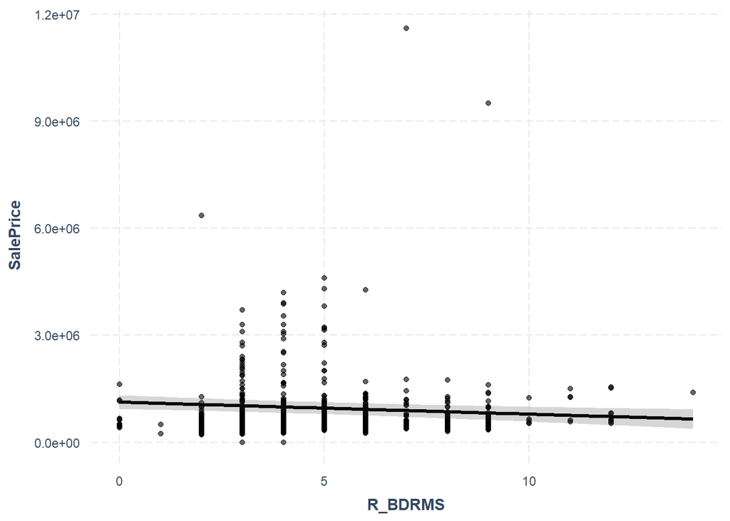

```r
## Plot of marginal response
effect_plot(reg1, pred = R_BDRMS, interval = TRUE, plot.points = TRUE)
```

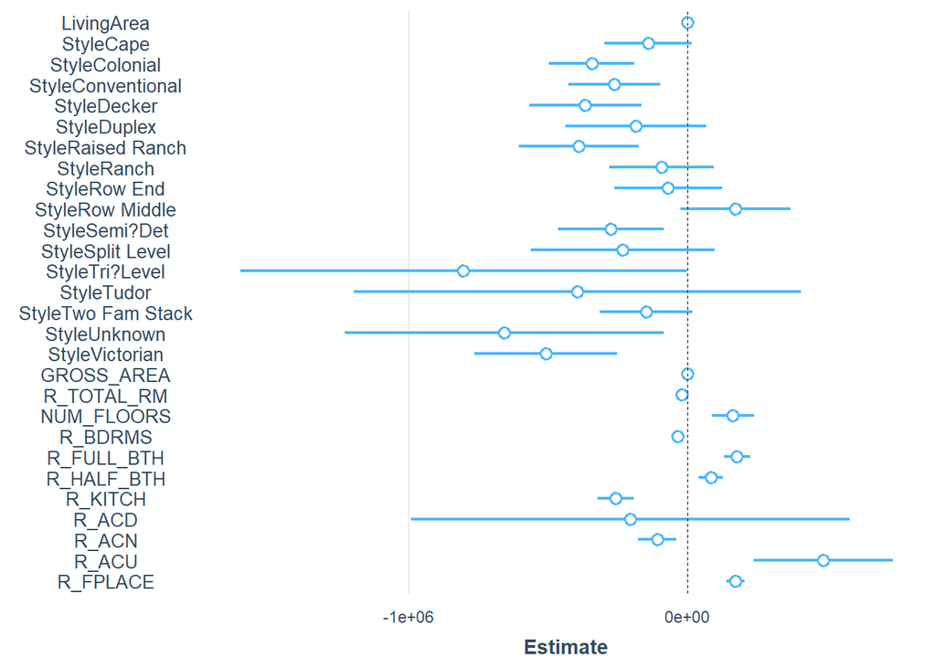

```r
## Plot coefficients
plot_summs(reg1)
```

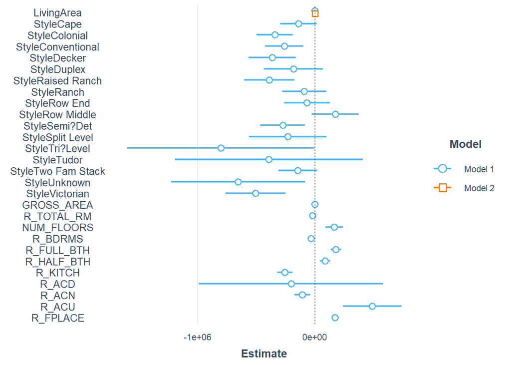

```r
## plot multiple model coeffs
plot_summs(reg1, livingReg)
```

## Try to engineer a ‘fixed effect’ out of the other variables in an attempt to parameterize a variable that suggests a big or fancy house or levels of fanciness.

## How does this affect your model?